**Instructor copy.** Executed notebook with all results shown, including the "after your attempt" cells. Projector/offline fallback; learners should use the notebook itself.

# f4f · Three components: a triangle, a plane and a landscape (advanced step 18, optional)

**In plain words.** Everything from the binary steps carries over to three components. The dots now sit on a triangle, the line under the dots becomes a tilted plane with three corner heights, and the gap curve becomes a landscape over the triangle. The cheapest mixture, the prices, column generation and the floor work exactly as before; only the pictures gain a dimension.

**Learning goals.** After this notebook you can

1. read a composition on a triangle and plot it;
2. solve the menu with three rows (amounts, B atoms, C atoms) and explain why three positive amounts are not three phases;
3. turn the three multipliers into the plane's corner heights $\mu_A$, $\mu_B$, $\mu_C$ and check that no menu dot lies below it;
4. run column generation with closed-form pricing and check it against an independent control, the Rachford–Rice equation;
5. (dive deeper) see why a non-ideal liquid makes the landscape harder, and how the number of cells grows with the dimension.

**What you need.** Steps 10–14 of the course, or notebooks f4c and f4d. Cards: the lever rule, reading a line, floor and ceiling, reduced cost, column generation, twin dots, the phase rule and a tie line.

| Section | What | Track | Time |
| --- | --- | --- | --- |
| 1 | Points on a triangle | main | 10 min |
| 2 | The menu has three rows | main | 15 min |
| 3 | The line becomes a plane | main | 10 min |
| 4 | The gap becomes a landscape | main | 10 min |
| 5 | Column generation and the Rachford–Rice control | main | 15 min |
| 6 | What gets harder | dive deeper | 15 min |
| 7 | Exercises | both | 20 min |

**The model.** The melting lens of step 03 part C (A melts at 1000 K, B at 1800 K) plus an invented third component C that melts at 1250 K. C is synthetic: its numbers were chosen for teaching. Both SOLID and LIQUID stay ideal solutions of A, B and C. The sample has overall composition $z=(0.50, 0.30, 0.20)$ for (A, B, C) at 1400 K.

**Coming from materials.** You know the ternary isothermal section with its tie lines. Here you read it as "which dots are used". A tie line joins the two coexisting compositions; the sample lies on it, and the lever rule is read along it. Tie lines cannot be drawn with a ruler from $z$: they point neither to a corner nor parallel to an edge.

**Coming from operations research.** A three-row LP over candidate columns. A basic solution uses at most three columns (support size). Gibbs' phase rule at fixed $T$ and $p$ generically allows up to three coexisting phases too, but this model has only two phase models and no miscibility gap, so a third positive amount is a twin dot, not a third phase. Pricing an ideal phase has a closed form.

**How to work.** Run the cells from top to bottom. In each "Your turn" cell, replace `None` with your value and run it: `check` says whether you match, without showing the answer. Cells marked *After your attempt* hold worked solutions.

```python
# Setup: run this cell first. Locally it finds the course folder; in Colab it
# downloads the tested course release and the locked package versions.
# In Colab, the first run then restarts the session on purpose and Colab reports
# a crash: that is expected. Run this cell again, then the rest of the notebook.
RELEASE = "main"
import os, pathlib, subprocess, sys, time
ROOT = next((p for p in (pathlib.Path.cwd(), *pathlib.Path.cwd().parents)
             if (p / "pyproject.toml").is_file() and (p / "course").is_dir()), None)
if ROOT is None and "google.colab" in sys.modules:
    ROOT = pathlib.Path("/content/CalphadIntro")
    if not ROOT.is_dir():
        clone = ["git", "clone", "-q", "--depth", "1", "--branch", RELEASE,
                 "https://github.com/ukerzel/CalphadIntro.git", str(ROOT)]
        git = dict(os.environ, GIT_TERMINAL_PROMPT="0")
        if subprocess.run(clone, env=git, capture_output=True).returncode:
            raise SystemExit(f"Could not download course release {RELEASE}: check the internet "
                             "connection and run this cell again.")
    if not (ROOT / ".colab-ready").exists():
        if subprocess.run([sys.executable, "-m", "pip", "install", "-q", "-r",
                           str(ROOT / "notebooks" / "requirements-colab.txt")]).returncode:
            raise SystemExit("Installing the course packages failed; run this cell again.")
        (ROOT / ".colab-ready").touch()
        # Colab has already loaded its own numpy; a fresh session is needed to use the installed versions.
        print("Installed the course's package versions. Colab now restarts this session and"
              " reports a crash; that is expected. When it has reconnected, run this cell again"
              " (it will not install twice), then the rest of the notebook.", flush=True)
        time.sleep(3)
        os.kill(os.getpid(), 9)
if ROOT is None:
    raise SystemExit("Open this notebook from the course folder (poetry run jupyter lab) or in Colab.")
os.chdir(ROOT)
sys.path.insert(0, str(ROOT))
from notebooks.helpers import check, confirm, database, show_versions
show_versions(RELEASE)
```

```
Course release main · Python 3.12.14
  numpy       2.5.3
  scipy       1.18.1
  matplotlib  3.11.2
  xarray      2026.7.0
  pycalphad   0.11.2
```

```
True
```

## 0. Numbers you may change, and the tools

Leave these as they are for the first run: the "Your turn" checks expect them. Later, change one number at a time and rerun everything below it.

- `T`: the temperature in K;
- `z`: the sample's overall composition (A, B, C), adding to 1;
- `MENU_N`: the menu is every point $(i, j, k)/n$ of the triangle with $n$ = `MENU_N`; with 12 the sample is not on the menu.

```python
T = 1400.0                 # K
z = (0.50, 0.30, 0.20)     # overall (A, B, C) atom fractions
MENU_N = 12                # 91 menu points per phase model
```

`day3_ternary` is the small course module that also produced the numbers of step 18. It holds the two ideal phase models (`g`), the menu solver with three rows (`solve_master`), the closed-form pricing (`price`) and the Rachford–Rice control (`rachford_rice`). Colours follow the website.

```python
import math
import numpy as np
import matplotlib.pyplot as plt
from course.self_study import day3_ternary as t3

SOLID_C, LIQUID_C, LINE_C = "#2445c4", "#cf4418", "#8f6400"   # the website's colours
R = t3.R                                                         # 8.3145 J/(mol K)
```

## 1. Points on a triangle (main track, 10 min)

A composition has three fractions that add to 1, so two numbers fix it. A triangle shows all of them at once: pure A at the corner $(0, 0)$, pure B at $(1, 0)$, pure C at $(1/2, \sqrt3/2)$. A composition $(x_A, x_B, x_C)$ sits at

$$X = x_B + x_C/2,\qquad Y = x_C\,\sqrt3/2 .$$

The further a point is from an edge, the more of the opposite corner's component it holds. The helper below does the conversion for a whole array.

```python
def to_xy(x):
    """Triangle coordinates of (A, B, C) fractions (one row per point)."""
    x = np.atleast_2d(x)
    return x[:, 1] + x[:, 2] / 2, x[:, 2] * np.sqrt(3) / 2

def frame(ax):
    """Draw the triangle and label its corners."""
    ax.plot([0, 1, 0.5, 0], [0, 0, np.sqrt(3) / 2, 0], color="black", lw=0.8)
    for label, (px, py) in (("A", (-0.04, -0.04)), ("B", (1.01, -0.04)), ("C", (0.48, 0.89))):
        ax.text(px, py, label)
    ax.set_aspect("equal"); ax.axis("off")
```

### Your turn: where is the sample?

Give the horizontal coordinate $X$ of $z=(0.50, 0.30, 0.20)$.

```python
X_z = None
check(X_z, "f4f_x_of_z")
```

```
f4f_x_of_z: not attempted yet. Replace None with your value and run the cell again.
```

## 2. The menu has three rows (main track, 15 min)

The menu is every grid point of the triangle, as a SOLID dot and as a LIQUID dot. The constraints now have three rows: amounts add to 1, B atoms add to $z_B$, C atoms add to $z_C$ (the A row follows from these).

**Predict first:** how many dots will the cheapest mixture use?

```python
menu = t3.grid(MENU_N)                                  # (A, B, C) for every grid point
phases = ["SOLID"] * len(menu) + ["LIQUID"] * len(menu)
states = np.vstack([menu, menu])
assert not any(np.allclose(p, z) for p in menu), "the sample is on the menu: choose another MENU_N"
master = t3.solve_master(phases, states, z, T)
print(f"{len(states)} dots; cheapest mixture G_up = {master.G_up:.2f} J/mol atoms")
```

```
182 dots; cheapest mixture G_up = -25277.64 J/mol atoms
```

```python
for p, x, f in zip(master.phases, master.x, master.f):
    if f > 0:
        print(f"uses {p:6s} at (A, B, C) = ({x[0]:.3f}, {x[1]:.3f}, {x[2]:.3f}): f = {f:.3f}")
f, x = master.f, master.x
assert abs(f.sum() - 1) < 1e-9, f"amounts sum to {f.sum():.6f}, not 1"
assert np.allclose(f @ x, z, atol=1e-9), f"the atoms add to {f @ x}, not z = {z}"
```

```
uses SOLID  at (A, B, C) = (0.417, 0.417, 0.167): f = 0.300
uses LIQUID at (A, B, C) = (0.500, 0.250, 0.250): f = 0.400
uses LIQUID at (A, B, C) = (0.583, 0.250, 0.167): f = 0.300
```

Three dots carry an amount: two neighbouring LIQUID dots and one SOLID dot. That is a small *tie triangle*: the true liquid composition lies between the two liquid dots, and the solver mixes them to get close. Three positive amounts here are not three phases: two of them are twin dots of one phase.

### Your turn: count

How many dots does the cheapest mixture use?

```python
n_used = None
check(n_used, "f4f_menu_used")
```

```
f4f_menu_used: not attempted yet. Replace None with your value and run the cell again.
```

## 3. The line becomes a plane (main track, 10 min)

With three rows the solver returns three multipliers $\pi_0, \pi_B, \pi_C$. They describe a plane over the triangle, $\pi_0 + \pi_B x_B + \pi_C x_C$. Its heights at the three corners are the chemical potentials:

$$\mu_A = \pi_0,\qquad \mu_B = \pi_0+\pi_B,\qquad \mu_C = \pi_0+\pi_C .$$

`master.mu` already holds the three corner heights. A dot's gap is its energy minus the plane's height there, $g(x)-\sum_i x_i\mu_i$.

```python
mu = master.mu
print(f"mu_A = {mu[0]:.1f}   mu_B = {mu[1]:.1f}   mu_C = {mu[2]:.1f}   (J/mol)")
for p in ("SOLID", "LIQUID"):
    gaps = t3.g(p, menu, T) - menu @ mu
    print(f"{p:6s}: lowest gap of the menu dots {gaps.min():.2e}")
    assert gaps.min() > -1e-8, f"a {p} dot lies {gaps.min():.3g} J/mol below the plane"
```

```
mu_A = -22733.0   mu_B = -23222.0   mu_C = -34722.5   (J/mol)
SOLID : lowest gap of the menu dots 0.00e+00
LIQUID: lowest gap of the menu dots 0.00e+00
```

The used dots sit on the plane (gap zero) and no dot lies below it: the plane is a floor for the menu, exactly as the line was on step 11.

### Your turn: one corner height

What is $\mu_C$, the plane's height at the C corner?

```python
mu_C = None   # J/mol
check(mu_C, "f4f_mu_c_menu")
```

```
f4f_mu_c_menu: not attempted yet. Replace None with your value and run the cell again.
```

## 4. The gap becomes a landscape (main track, 10 min)

Draw the gap of every composition of a phase model, not only the menu dots, as a colour map over the triangle. Blue is above the plane, red below it.

**Predict first:** will the landscape dip below zero somewhere between the dots, as the gap curve did on step 12?

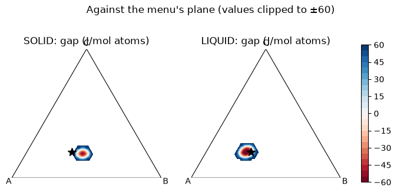

```
{'SOLID': np.float64(-36.733147605173144), 'LIQUID': np.float64(-77.53678651691371)}
```

```python
fine = t3.grid(60)
FX, FY = to_xy(fine)

def landscape(mu_plane, title):
    fig, axes = plt.subplots(1, 2, figsize=(9, 3.8))
    for ax, p in zip(axes, ("SOLID", "LIQUID")):
        gap = t3.g(p, fine, T) - fine @ mu_plane
        im = ax.tricontourf(FX, FY, np.clip(gap, -60, 60), levels=24, cmap="RdBu")
        frame(ax); ax.plot(*to_xy(np.array(z)), "k*", ms=10); ax.set_title(f"{p}: gap (J/mol atoms)")
    fig.colorbar(im, ax=axes, shrink=0.8); fig.suptitle(title); plt.show()
    return {p: (t3.g(p, fine, T) - fine @ mu_plane).min() for p in ("SOLID", "LIQUID")}

print(landscape(mu, "Against the menu's plane (values clipped to ±60)"))
```

Both landscapes dip below zero between the dots: the menu's plane is a floor for the menu, not for every state. Each phase model's deepest point has a formula, because both phase models are ideal:

$$x_i \propto e^{-(g^\circ_i-\mu_i)/RT},\qquad \text{depth} = -RT\ln\sum_i e^{-(g^\circ_i-\mu_i)/RT}.$$

`t3.price` applies it.

```python
for p in ("SOLID", "LIQUID"):
    xd, depth = t3.price(p, mu, T)
    print(f"{p:6s}: deepest point ({xd[0]:.4f}, {xd[1]:.4f}, {xd[2]:.4f}), gap {depth:.2f} J/mol atoms")
    lowest = (t3.g(p, fine, T) - fine @ mu).min()
    assert depth <= lowest + 1e-9, "the formula should be at or below every grid point"
```

```
SOLID : deepest point (0.4320, 0.3801, 0.1879), gap -37.57 J/mol atoms
LIQUID: deepest point (0.5291, 0.2686, 0.2023), gap -77.98 J/mol atoms
```

## 5. Column generation and the Rachford–Rice control (main track, 15 min)

Add the deepest state, solve again, repeat: column generation, as in step 13. The floor is the plane lowered by the deepest dip, read at $z$; as in step 14, the helper keeps the best floor so far. One round per row.

```python
rounds = t3.column_generation(seed_n=MENU_N, z=z, t=T, tol=1e-4, max_iter=60)
print(" round   ceiling       deepest dip   remaining")
for r in rounds:
    print(f"{r['k']:5d}  {r['master'].G_up:11.3f}  {r['dips'][r['best']][1]:11.5f}  {r['remaining']:10.5f}")
```

```
 round   ceiling       deepest dip   remaining
    0   -25277.636    -77.97657    77.97657
    1   -25328.443    -68.67215    27.17025
    2   -25338.632    -22.20921    16.98151
    3   -25342.484     -7.11549     7.11549
    4   -25343.586     -2.09423     2.09423
    5   -25344.369     -1.03499     1.03499
    6   -25344.793     -0.61878     0.61139
    7   -25344.935     -0.25806     0.25806
    8   -25345.061     -0.06476     0.06476
    9   -25345.097     -0.01619     0.01619
   10   -25345.104     -0.03301     0.00936
   11   -25345.112     -0.00405     0.00180
   12   -25345.112     -0.00101     0.00101
   13   -25345.112     -0.00209     0.00086
   14   -25345.113     -0.00025     0.00025
   15   -25345.113     -0.00006     0.00006
```

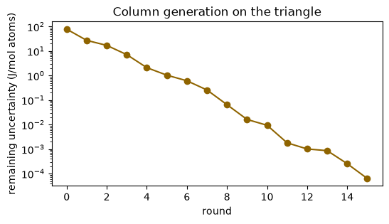

```python
ups = [r["master"].G_up for r in rounds]
assert all(b <= a + 1e-9 for a, b in zip(ups, ups[1:])), "the ceiling rose: the master lost a column"
fig, ax = plt.subplots(figsize=(6, 3))
ax.semilogy([r["k"] for r in rounds], [max(r["remaining"], 1e-12) for r in rounds], "o-", color=LINE_C)
ax.set(xlabel="round", ylabel="remaining uncertainty (J/mol atoms)", title="Column generation on the triangle"); plt.show()
```

**An independent control.** For two ideal phases the split follows from the partition ratios $K_i = x_{L,i}/x_{S,i} = e^{(g^\circ_{S,i}-g^\circ_{L,i})/RT}$. The liquid amount $V$ solves the Rachford–Rice equation

$$\sum_i \frac{z_i (K_i-1)}{1+V(K_i-1)} = 0,\qquad 0<V<1,$$

whose left side decreases with $V$ and has one root on $(0,1)$ when a split exists. It uses no grid and no LP at all.

```python
K = t3.partition(T)
rr = t3.rachford_rice(z, T)
print("K =", K.round(4), "  V =", round(rr["V"], 4))
print("solid  ", rr["x_SOLID"].round(4), "\nliquid ", rr["x_LIQUID"].round(4))
confirm(rr["V"], 0.770823, "The liquid amount from Rachford–Rice", tol=1e-5)
```

```
K = [1.229  0.7092 1.0804]   V = 0.7708
solid   [0.425  0.3867 0.1883]
liquid  [0.5223 0.2742 0.2035]
✓ The liquid amount from Rachford–Rice reproduces the lesson value.
```

Compare: the states column generation ended with sit at the Rachford–Rice compositions (twin columns of one phase have nearly the same composition).

```python
last = rounds[-1]["master"]
for p, x, f in zip(last.phases, last.x, last.f):
    if f > 1e-9:
        target = rr["x_SOLID"] if p == "SOLID" else rr["x_LIQUID"]
        print(f"{p:6s} f = {f:.4f}  at {x.round(4)}  (Rachford–Rice {target.round(4)})")
        assert np.allclose(x, target, atol=2e-3), f"a {p} state is far from the Rachford–Rice composition"
liquid = sum(f for p, f in zip(last.phases, last.f) if p == "LIQUID")
print(f"total liquid amount {liquid:.4f}  against V = {rr['V']:.4f}")
```

```
LIQUID f = 0.1512  at [0.5224 0.2742 0.2034]  (Rachford–Rice [0.5223 0.2742 0.2035])
SOLID  f = 0.2292  at [0.425  0.3867 0.1883]  (Rachford–Rice [0.425  0.3867 0.1883])
LIQUID f = 0.6196  at [0.5223 0.2742 0.2035]  (Rachford–Rice [0.5223 0.2742 0.2035])
total liquid amount 0.7708  against V = 0.7708
```

The edges of the triangle are binaries. On the A–B edge the lens of step 03 returns (liquid 0.312, solid 0.441 in B); on the C–B edge the band is narrower; the A–C edge is all liquid at 1400 K.

```python
for pair in (("A", "B"), ("C", "B"), ("A", "C")):
    tie = t3.edge_tie(pair, T)
    print(f"{pair[0]}–{pair[1]} edge:", "all one phase" if tie is None else f"solid {tie[0]:.3f}, liquid {tie[1]:.3f} in {pair[1]}")
```

```
A–B edge: solid 0.441, liquid 0.312 in B
C–B edge: solid 0.217, liquid 0.154 in B
A–C edge: all one phase
```

### Your turn: the control

1. What fraction of the sample is liquid?
2. What is $x_B$ of the coexisting liquid?
3. On the C–B edge, what is the B fraction of the liquid?

```python
V_answer = None
xB_liquid = None
cb_liquid = None
check(V_answer, "f4f_V")
check(xB_liquid, "f4f_xb_liquid")
check(cb_liquid, "f4f_cb_liquid")
```

```
f4f_V: not attempted yet. Replace None with your value and run the cell again.
f4f_xb_liquid: not attempted yet. Replace None with your value and run the cell again.
f4f_cb_liquid: not attempted yet. Replace None with your value and run the cell again.
```

## 6. What gets harder (dive deeper, 15 min)

Give the liquid an energy cost for A–C neighbours, $\Omega\,x_Ax_C$ with $\Omega = 30000$ J/mol. On the A–C edge that is more than $2RT$, so the liquid can split into an A-rich and a C-rich liquid: its landscape is no longer convex and the closed-form pricing no longer applies.

Take the tangent plane of this liquid at the A-rich point (0.75, 0.05, 0.20) and look at the landscape against it.

```python
at = np.array(t3.HARDER_AT)
mu_at = t3.mu_with_ac(at, T)
gap_at = float(t3.g_with_ac("LIQUID", at, T) - at @ mu_at)
print(f"tangent plane at {at}: corner heights {mu_at.round(1)}; gap there {gap_at:.2e}")
near = fine[np.linalg.norm(fine - at, axis=1) < 0.06]
print(f"lowest gap within 0.06 of the tangent point: {(t3.g_with_ac('LIQUID', near, T) - near @ mu_at).min():.3f}")
```

```
tangent plane at [0.75 0.05 0.2 ]: corner heights [-17248.7 -47371.2 -16934.3]; gap there 0.00e+00
lowest gap within 0.06 of the tangent point: 0.000
```

Near the tangent point nothing lies below the plane: a local search started there stops at once. A full scan of the triangle tells a different story.

```
full scan: deepest point [0.119 0.044 0.838], gap -727.1 J/mol atoms
```

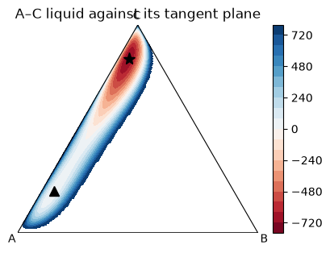

```python
scan = t3.grid(160)
gap_scan = t3.g_with_ac("LIQUID", scan, T) - scan @ mu_at
k = int(np.argmin(gap_scan))
print(f"full scan: deepest point {scan[k].round(3)}, gap {gap_scan[k]:.1f} J/mol atoms")
fig, ax = plt.subplots(figsize=(4.8, 4.2))
sx, sy = to_xy(scan)
im = ax.tricontourf(sx, sy, np.clip(gap_scan, -800, 800), levels=24, cmap="RdBu")
frame(ax); ax.plot(*to_xy(at), "k^", ms=8); ax.plot(*to_xy(scan[k]), "k*", ms=11)
fig.colorbar(im, ax=ax, shrink=0.8); ax.set_title("A–C liquid against its tangent plane"); plt.show()
```

The valley sits far away, on the C-rich side: the triangle version of step 15. On a triangle, a proof that no valley is left needs floors on small triangles instead of intervals, and the number of cells grows fast with the dimension $d$: cutting every direction into pieces of width $h$ gives about $(1/h)^d$ cells of a cube, about $(1/h)^d/d!$ on the composition simplex. That is the uniform worst case; branch-and-bound refines only near the touching points, but each split still makes several smaller cells.

```python
for h in (0.1, 0.01):
    print(f"h = {h}: " + ",  ".join(f"d = {d}: {math.comb(round(1 / h) + d, d):.0e} grid points on the simplex" for d in (1, 2, 9)))
```

```
h = 0.1: d = 1: 1e+01 grid points on the simplex,  d = 2: 7e+01 grid points on the simplex,  d = 9: 9e+04 grid points on the simplex
h = 0.01: d = 1: 1e+02 grid points on the simplex,  d = 2: 5e+03 grid points on the simplex,  d = 9: 4e+12 grid points on the simplex
```

### Your turn: the hidden valley

How deep is the hidden valley found by the full scan (a negative number, J/mol atoms)?

```python
hidden_depth = None
check(hidden_depth, "f4f_hidden_depth")
```

```
f4f_hidden_depth: not attempted yet. Replace None with your value and run the cell again.
```

## 7. Exercises

**Materials flavour: run, change one number, explain.**

- Set `z = (0.40, 0.40, 0.20)` in section 0 and rerun. Does the sample still split? Read the new tie line: does it point to a corner?
- Set `MENU_N = 24` and rerun. How many dots are used now, and how far is the ceiling above the Rachford–Rice energy?

**Optimisation flavour: complete a function, then one deeper exercise.**

Complete `plane_heights`: given the three multipliers $(\pi_0, \pi_B, \pi_C)$, return the corner heights $(\mu_A, \mu_B, \mu_C)$.

```python
def plane_heights(pi0, piB, piC):
    """Corner heights of the plane pi0 + piB xB + piC xC."""
    return None   # replace with (mu_A, mu_B, mu_C)

guess = plane_heights(master.mu[0], master.mu[1] - master.mu[0], master.mu[2] - master.mu[0])
check(None if guess is None else guess[2], "f4f_mu_c_menu")
```

```
f4f_mu_c_menu: not attempted yet. Replace None with your value and run the cell again.
```

```python
#@title After your attempt: a solution of plane_heights
def plane_heights_solution(pi0, piB, piC):
    return pi0, pi0 + piB, pi0 + piC     # the plane's height at (1,0,0), (0,1,0) and (0,0,1)

print(plane_heights_solution(master.mu[0], master.mu[1] - master.mu[0], master.mu[2] - master.mu[0]))
```

```
(np.float64(-22733.042140779555), np.float64(-23222.029094091315), np.float64(-34722.53337958116))
```

**Deeper exercise (operations research).** Write your own Rachford–Rice solver: first the existence test (a split exists only if $\sum_i z_iK_i>1$ and $\sum_i z_i/K_i>1$), then bisection on $(0, 1)$, where the function is monotone. Compare $V$ and the compositions with `t3.rachford_rice`.

```python
#@title After your attempt: a bracketed Rachford–Rice solver
def my_rachford_rice(z, K, tol=1e-14):
    z, K = np.asarray(z, float), np.asarray(K, float)
    if (z * K).sum() <= 1 or (z / K).sum() <= 1:
        return None                                   # one phase only: no root in (0, 1)
    f = lambda v: (z * (K - 1) / (1 + v * (K - 1))).sum()
    lo, hi = 0.0, 1.0                                 # f(0) > 0 > f(1) when a split exists
    while hi - lo > tol:
        mid = 0.5 * (lo + hi)
        lo, hi = (mid, hi) if f(mid) > 0 else (lo, mid)
    v = 0.5 * (lo + hi)
    xs = z / (1 + v * (K - 1))
    return v, xs, K * xs

v, xs, xl = my_rachford_rice(z, K)
print(round(v, 6), xs.round(4), xl.round(4))
assert abs(v - rr["V"]) < 1e-9 and np.allclose(xs, rr["x_SOLID"]) and np.allclose(xl, rr["x_LIQUID"])
```

```
0.770823 [0.425  0.3867 0.1883] [0.5223 0.2742 0.2035]
```

## Recap

- A ternary composition is a point on a triangle; the menu is a grid of points, as SOLID and as LIQUID dots.
- The menu LP has three rows; its cheapest mixture uses at most three dots. Here two of them are twin LIQUID dots: a tie triangle, not three phases.
- The three multipliers give a plane whose corner heights are $\mu_A$, $\mu_B$, $\mu_C$; it is a floor for the menu only.
- Closed-form pricing and column generation reach the split that the Rachford–Rice equation gives without any grid.
- A non-ideal liquid hides valleys, and checks on a uniform grid grow like $(1/h)^d$ (branch-and-bound needs fewer pieces, but still many more in more dimensions).

**Next:** back to the website; step 18 shows these pictures in the triangle lab. Cards: the phase rule and a tie line, twin dots, column generation, local and global minimum.

**If a cell fails:** rerun the setup cell first; then check that section 0 still has its original numbers.